# project1

Liwei Zhang

January 31, 2019

[figure not shown]

## Method1: Sentiment analysis

#### Things to cheer people up

To see generally what happens usually at people’s happy monents, I use NRC Lexicons to find the most frequent sentiment words.

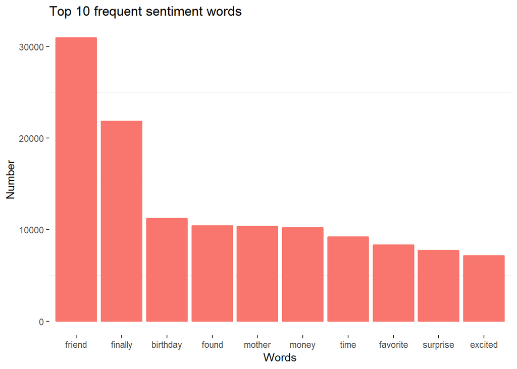

We love our friends! Also, we love our parents and money of course!

#### Sentiment comparison within groups

I want to find whether there is a difference of sentiment expressions between female and male groups or married and single groups. To examine it, I first divide the data into female and male as well as married and single, respectively. After that, I compute the frequency of the use of sentiment words and scale the frequency by the total sentence number of each group. Here are two plots below that show the scaled frequency for each group. Notice that the y axis value represents no physical meaning but a scaled value, so here I hide the y axis value.

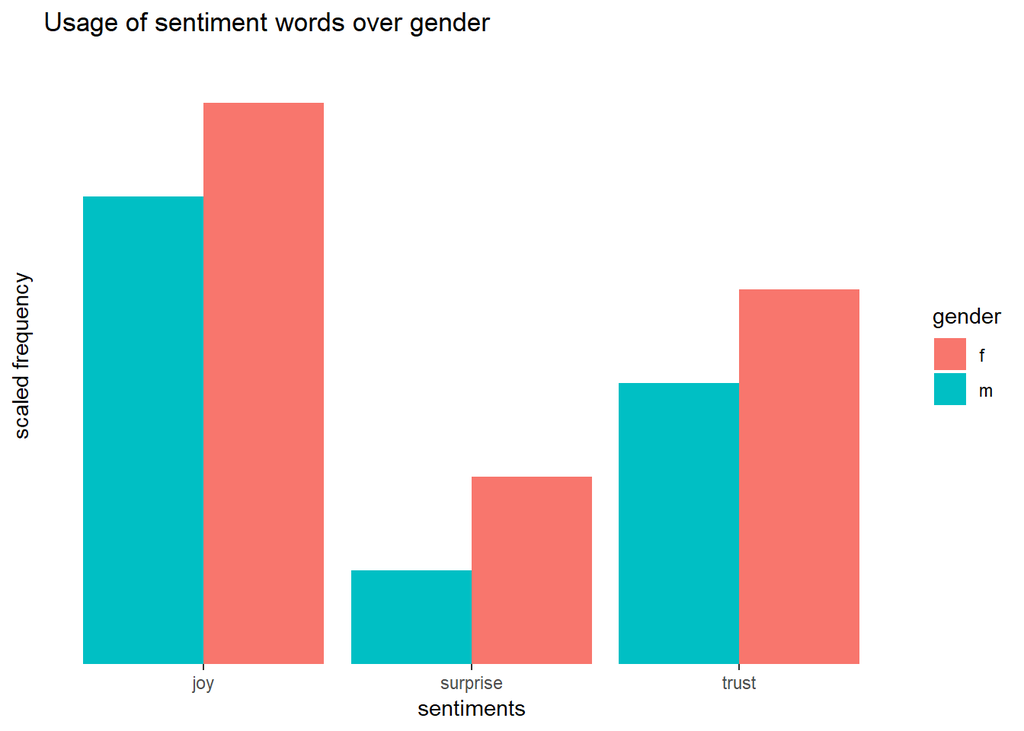

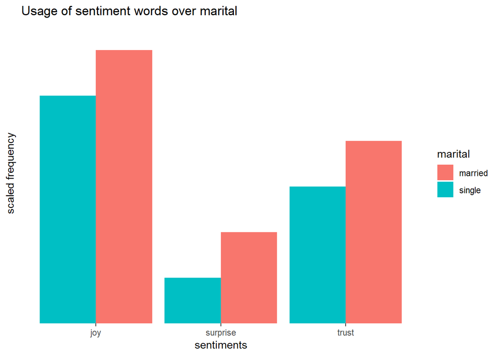

### Conclusion under sentiment analysis:

- Compared to male group, female group shows stronger sentiments by having higher scaled frequency of using sentiment words.
- Compared to single group, married group shows stronger sentiments by having higher scaled frequency of using sentiment words.
- For all groups, they enjoyed the moment of joy the most, then that of trust and then that of surprise.

## Method2: tf-idf

### Single and married comparison

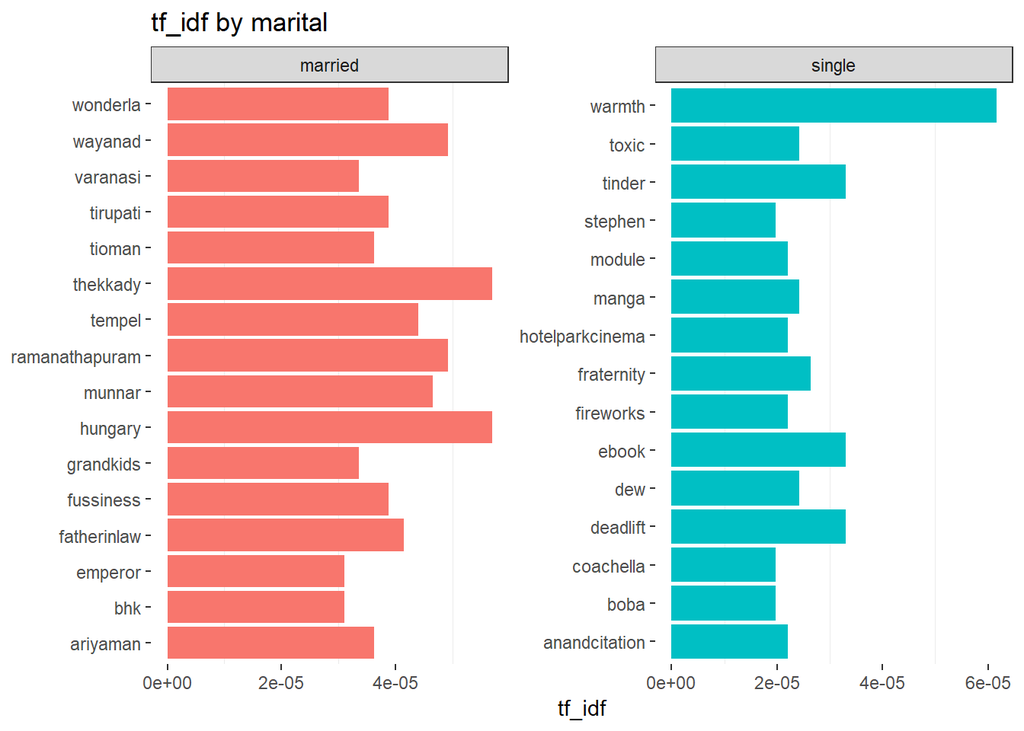

### Single

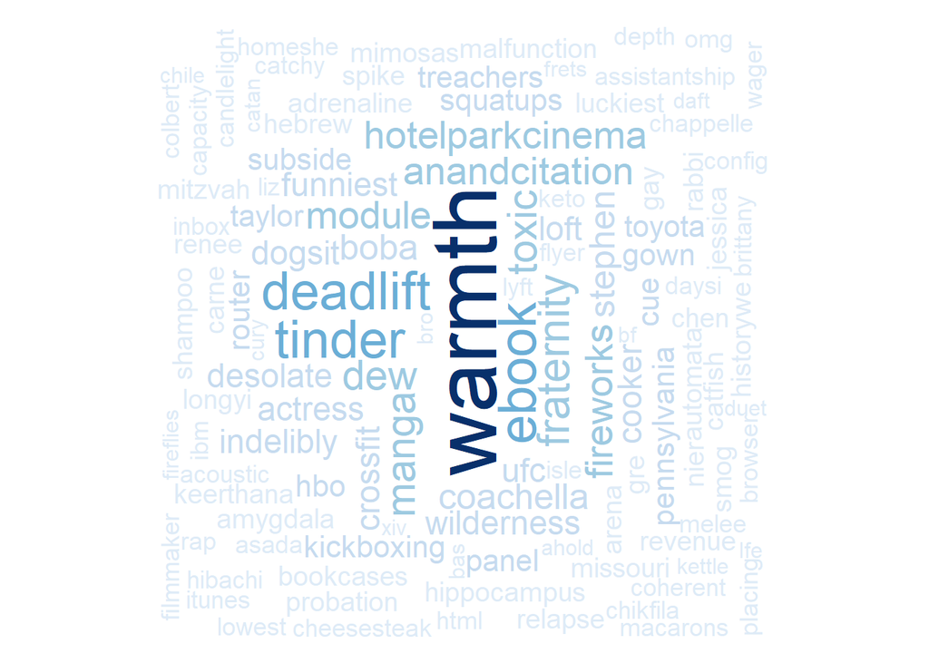

Under tf-idf method, what single people enjoy is as followed.

- Single life: tinder, Coachella(music festival)
- Fraternities and Sororities: Fraternities, Manga
- Nature: warmth, rain dew
- Work: finish online module
- Exercise and weightlift: deadlift
- Comfort food: boba tea

### Married

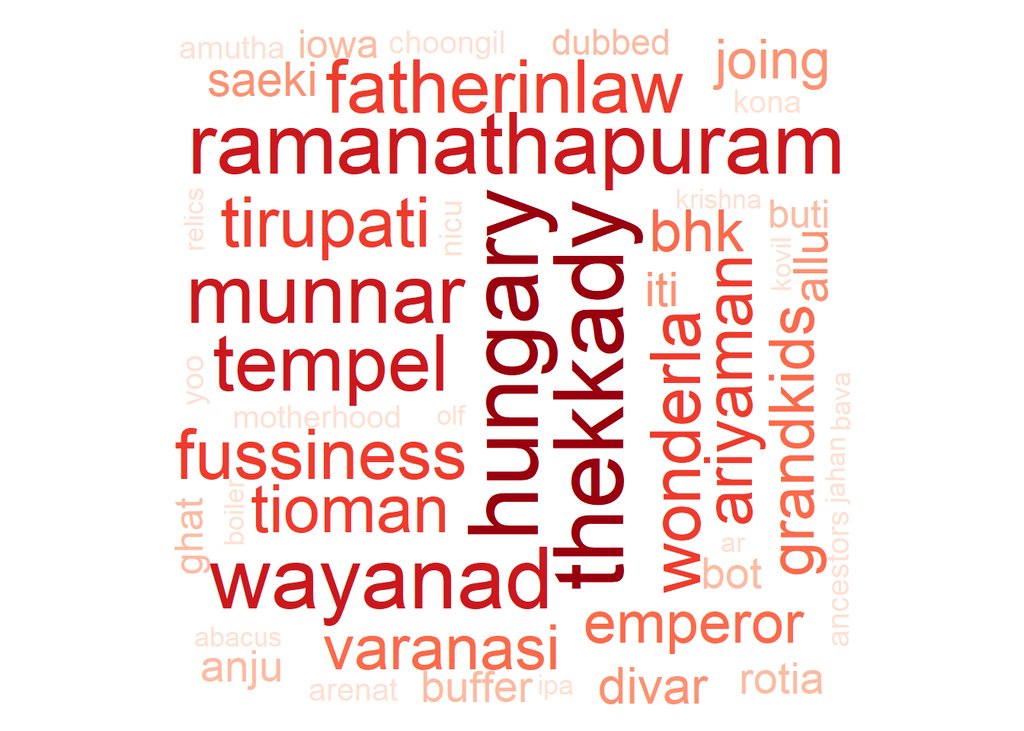

Under tf-idf method, what married people enjoy is as followed.

- Family trips: Wonderla(amusement park); Wayanad, Tioman, Ariyaman(tourist attractions); Munnar,Thekkady(national park)
- Family life: grandkids, father-in-law
- Real estate purchases: bhk(one bedroom, one hall and one kitchen apartment)

### Conclusion under tf-idf:

- Married people tend to enjoy family time more and settle down in life.
- Single people enjoy personal life more in both self-entertainment and personal development.

# Method3: LDA

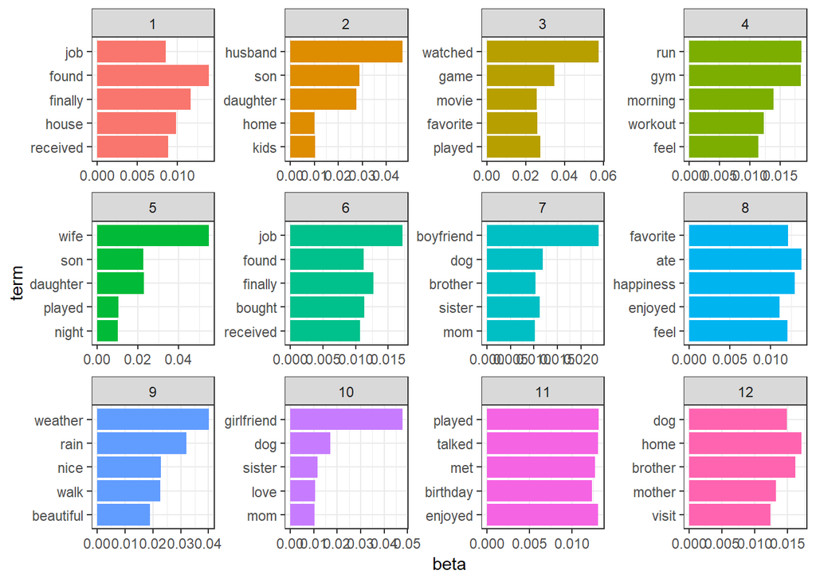

### Conclusion under LDA:

When using the method, I combine prediction_category, gender and marital together as the termdocument.

We picked 12 topics in this case. We can describe the topics as 12 individuals.

# Summary

After using Sentiment Analysis, tf-idf and LDA method, we could obtain the results as followed.

- Everyone loves friends! “Friends” is the No.1 count word in the sentiment analysis!
- Married people and female are better at expressing their happiness with more use of sentiment words. To some degree, they might be actually happier than the other party(a.k.a. single people and male).
- Married people having more fun with family. Taking a family trip is a nice way for them to enjoy the life. They also have more needs to settle down. However, single people have more diverse hobbies. They enjoy life by improving themselves as well as hanging out with peers.
- Single person cherishes his/her family relationship with their siblings as well as and romantic relationship with his/her girl/boy friend. He/she loves exercises, food, video games, pets and many other things.
- Married person cheriches his/her family relationship more with their wife/husband and kids. He/she enjoys more getting a decent job.